# Step5_Phylogenetic Meta-Analysis

Keisuke Atsumi

18/08/12 20:39

## *Phylogenetic data*

Obtained from NCBI taxonomy, thus represents distance in taxonomical tree.  
Polytomies were solved randomly using R, not utilizing phylogenetic studies of focal organisms.

# Reciprocal cross

Test this hypothesis by examining whether ln(hybLS / hybSL) is significantly differ from 0.  
hybLS: hybrids whose mother is the larger species (spL).  
hybSL: hybrids whose mother is the smaller species (spS).

if LnRR = 0 -> No phenotypic difference between cross direction  
if 0 < LnRR -> Hybrid SL < Hybrid LS  
if LnRR < 0 -> Hybrid LS < Hybrid SL

```r
########################################
# random effect model
########################################
recip.lnRR_random <- rma.mv(yi = lnRR.recip.es, V = lnRR.recip.sv,
                            method = "REML", data = ES.recip.lnRR,
                            random = list(~1 | spL.name, ~1 | Study.ID)
                       )
 # ~1 | ES.ID as a random effect is required
summary(recip.lnRR_random)
```

```
##
## Multivariate Meta-Analysis Model (k = 82; method: REML)
##
##   logLik  Deviance       AIC       BIC      AICc
## -97.3399  194.6797  200.6797  207.8631  200.9914
##
## Variance Components:
##
##             estim    sqrt  nlvls  fixed    factor
## sigma^2.1  0.0138  0.1175     22     no  spL.name
## sigma^2.2  0.0000  0.0000     16     no  Study.ID
##
## Test for Heterogeneity:
## Q(df = 81) = 81.1955, p-val = 0.4730
##
## Model Results:
##
## estimate      se    zval    pval    ci.lb   ci.ub
##   0.0564  0.0377  1.4928  0.1355  -0.0176  0.1303
##
## ---
## Signif. codes:  0 '***' 0.001 '**' 0.01 '*' 0.05 '.' 0.1 ' ' 1
```

```r
########################################
# phylogenetic random effect model
########################################
recip.lnRR_phyl.random <- rma.mv(yi = lnRR.recip.es, V = lnRR.recip.sv,
                            method = "REML", data = ES.recip.lnRR,
                            random = list(~1 | spL.name, ~1 | Study.ID, ~1 | ES.ID),
                            R = list(spL.name = tree.spL.recip.lnRR.random.cor)
                            )
 # ~1 | ES.ID as a random effect is required
summary(recip.lnRR_phyl.random)
```

```
##
## Multivariate Meta-Analysis Model (k = 82; method: REML)
##
##   logLik  Deviance       AIC       BIC      AICc
## -96.2444  192.4888  200.4888  210.0666  201.0151
##
## Variance Components:
##
##             estim    sqrt  nlvls  fixed    factor    R
## sigma^2.1  0.0000  0.0000     22     no  spL.name  yes
## sigma^2.2  0.0000  0.0000     16     no  Study.ID   no
## sigma^2.3  0.0108  0.1040     82     no     ES.ID   no
##
## Test for Heterogeneity:
## Q(df = 81) = 81.1955, p-val = 0.4730
##
## Model Results:
##
## estimate      se    zval    pval   ci.lb   ci.ub
##   0.0661  0.0289  2.2861  0.0222  0.0094  0.1228  *
##
## ---
## Signif. codes:  0 '***' 0.001 '**' 0.01 '*' 0.05 '.' 0.1 ' ' 1
```

```r
# I^2 see http://www.metafor-project.org/doku.php/tips:i2_multilevel_multivariate?s[]=rma&s[]=mv&s[]=i2
W <- diag(1/ES.recip.lnRR$lnRR.recip.sv)
X <- model.matrix(recip.lnRR_phyl.random)
P <- W - W %*% X %*% solve(t(X) %*% W %*% X) %*% t(X) %*% W
100 * sum(recip.lnRR_phyl.random$sigma2) / (sum(recip.lnRR_phyl.random$sigma2) +
                                         (recip.lnRR_phyl.random$k-recip.lnRR_phyl.random$p)/sum(diag(P)))
```

```
## [1] 35.03049
```

```r
########################################
# regression with random effect including phylogeny
########################################
recip.lnRR_phyl.random.reg <- rma.mv(yi = lnRR.recip.es, V = lnRR.recip.sv,
                                method = "REML", data = ES.recip.lnRR,
                                random = list(~1 | spL.name, ~1 | Study.ID),
                                R = list(spL.name = tree.spL.recip.lnRR.random.cor),
                                mods = ~divergence + trait.type + lnL.lnS + hetero.males
                                )
summary(recip.lnRR_phyl.random.reg)
```

```
##
## Multivariate Meta-Analysis Model (k = 48; method: REML)
##
##   logLik  Deviance       AIC       BIC      AICc
## -69.3598  138.7196  152.7196  165.0480  155.9196
##
## Variance Components:
##
##             estim    sqrt  nlvls  fixed    factor    R
## sigma^2.1  0.0976  0.3123     13     no  spL.name  yes
## sigma^2.2  0.0000  0.0000      8     no  Study.ID   no
##
## Test for Residual Heterogeneity:
## QE(df = 43) = 40.7471, p-val = 0.5695
##
## Test of Moderators (coefficient(s) 2:5):
## QM(df = 4) = 0.8176, p-val = 0.9361
##
## Model Results:
##
##               estimate      se     zval    pval    ci.lb   ci.ub
## intrcpt         0.0535  0.2502   0.2139  0.8306  -0.4368  0.5438
## divergence     -0.0109  0.0167  -0.6536  0.5134  -0.0437  0.0218
## trait.type     -0.0019  0.2433  -0.0079  0.9937  -0.4788  0.4750
## lnL.lnS         0.0500  0.0864   0.5787  0.5628  -0.1193  0.2193
## hetero.males    0.0182  0.1057   0.1721  0.8633  -0.1890  0.2254
##
## ---
## Signif. codes:  0 '***' 0.001 '**' 0.01 '*' 0.05 '.' 0.1 ' ' 1
```

```r
########################################
# effect of species
########################################
# This basically uses spL.name as a factor and "-1" will make it return an intercept estimate for every level of this factor
rma.mv(yi = lnRR.recip.es, V = lnRR.recip.sv,
                                method = "REML", data = ES.recip.lnRR,
                                random = list(~1 | spL.name, ~1 | Study.ID, ~1 | ES.ID),
                                R = list(spL.name = tree.spL.recip.lnRR.random.cor),
                                mods = ~spL.name -1
                                )
```

```
##
## Multivariate Meta-Analysis Model (k = 82; method: REML)
##
## Variance Components:
##
##             estim    sqrt  nlvls  fixed    factor    R
## sigma^2.1  0.0069  0.0830     22     no  spL.name  yes
## sigma^2.2  0.0069  0.0830     16     no  Study.ID   no
## sigma^2.3  0.0033  0.0571     82     no     ES.ID   no
##
## Test for Residual Heterogeneity:
## QE(df = 60) = 16.1644, p-val = 1.0000
##
## Test of Moderators (coefficient(s) 1:22):
## QM(df = 22) = 17.8907, p-val = 0.7125
##
## Model Results:
##
##                                            estimate       se     zval
## spL.nameChorthippus_biguttulus              -0.0722   0.1335  -0.5409
## spL.nameChorthippus_brunneus                 0.2562   0.2013   1.2725
## spL.nameChorthippus_parallelus_eythropus     0.0374   0.1261   0.2963
## spL.nameChorthippus_parallelus_parallelus    0.5942   1.3318   0.4461
## spL.nameChrysoperla_johnsoni                 0.1715   0.5224   0.3283
## spL.nameCoturnix_coturnix_coturnix           0.0940   0.1947   0.4828
## spL.nameCoturnix_coturnix_japonica          -0.0905   0.1927  -0.4698
## spL.nameDrosophila_flavomontana              0.2954   0.1558   1.8961
## spL.nameDrosophila_lummei                    0.0991  10.7757   0.0092
## spL.nameDrosophila_persimilis               -0.1539   0.1616  -0.9522
## spL.nameDrosophila_silvestris                0.2772   0.1461   1.8969
## spL.nameDrosophila_simulans                 -0.0203   0.1450  -0.1402
## spL.nameDrosophila_virilis                   0.0081   0.6764   0.0120
## spL.nameGryllus_texensis                     0.1295   0.1290   1.0037
## spL.nameHyla_chrysoscelis                    0.1484   0.6055   0.2451
## spL.nameHyla_femoralis                       0.0421   1.8301   0.0230
## spL.nameLaupala_kohalensis                   0.0521   0.1396   0.3732
## spL.namePundamilia_nyererei                 -0.0179   0.1610  -0.1114
## spL.namePundamilia_pundamilia                0.0322   2.4236   0.0133
## spL.nameSpodoptera_latifascia               -0.0148   0.7520  -0.0197
## spL.nameTeleogryllus_commodus                0.1438   0.1357   1.0602
```

[output cut: 12 more lines]

```
## spL.nameDrosophila_silvestris              0.0578   -0.0092   0.5635  .
## spL.nameDrosophila_simulans                0.8885   -0.3045   0.2639
## spL.nameDrosophila_virilis                 0.9904   -1.3177   1.3339
## spL.nameGryllus_texensis                   0.3155   -0.1234   0.3823
## spL.nameHyla_chrysoscelis                  0.8064   -1.0384   1.3352
## spL.nameHyla_femoralis                     0.9816   -3.5448   3.6291
## spL.nameLaupala_kohalensis                 0.7090   -0.2215   0.3257
## spL.namePundamilia_nyererei                0.9113   -0.3335   0.2976
## spL.namePundamilia_pundamilia              0.9894   -4.7179   4.7824
## spL.nameSpodoptera_latifascia              0.9842   -1.4888   1.4591
## spL.nameTeleogryllus_commodus              0.2891   -0.1221   0.4097
## spL.nameTeleogryllus_oceanicus             0.4685   -0.4348   0.2000
##
## ---
## Signif. codes:  0 '***' 0.001 '**' 0.01 '*' 0.05 '.' 0.1 ' ' 1
```

```r
########################################
# output results
########################################

# random meta-analysis
recip.lnRR.r <- cbind(recip.lnRR_random$beta,   # estimate
                 recip.lnRR_random$ci.lb,  # 95ci
                 recip.lnRR_random$ci.ub,  # 95ci
                 "meta-analysis",
                 "meta-analytic mean"
                 )
colnames(recip.lnRR.r) <- c("estimate", "ci.lb", "ci.ub", "type", "factors")
row.names(recip.lnRR.r) <- "meta-analysis"
write.table(recip.lnRR.r, "../Analysis/random_recip.lnRR.csv",
            sep = ",", quote = F, row.names = T)

# random meta-regression
recip.lnRR.reg <- cbind(recip.lnRR_phyl.random.reg$beta,   # regression: estimate
                   recip.lnRR_phyl.random.reg$ci.lb,  # regression: 95ci
                   recip.lnRR_phyl.random.reg$ci.ub,   # regression: 95ci
                   "regression"
                   )
recip.lnRR.reg <- cbind(recip.lnRR.reg,
                   rownames(recip.lnRR.reg) # factors
                   )
colnames(recip.lnRR.reg) <- c("estimate", "ci.lb", "ci.ub", "type", "factors")
write.table(recip.lnRR.reg, "../Analysis/reg.recip.lnRR.csv",
            sep = ",", quote = F, row.names = T)

# all
recip.lnRR <- rbind(recip.lnRR.r, recip.lnRR.reg)
write.table(recip.lnRR, "../Analysis/recip.lnRR.csv",
            sep = ",", quote = F, row.names = T)
```

```r
########################################
# random effect model
########################################
recip.SMD_random <- rma.mv(yi = SMD.recip.es, V = SMD.recip.sv,
                            method = "REML", data = ES.recip.lnRR,
                            random = list(~1 | spL.name, ~1 | Study.ID)
                       )
 # ~1 | ES.ID as a random effect is required
summary(recip.SMD_random)
```

```
##
## Multivariate Meta-Analysis Model (k = 82; method: REML)
##
##    logLik   Deviance        AIC        BIC       AICc
## -132.1616   264.3232   270.3232   277.5065   270.6349
##
## Variance Components:
##
##             estim    sqrt  nlvls  fixed    factor
## sigma^2.1  0.1053  0.3245     22     no  spL.name
## sigma^2.2  1.8748  1.3693     16     no  Study.ID
##
## Test for Heterogeneity:
## Q(df = 81) = 616.2406, p-val < .0001
##
## Model Results:
##
## estimate      se    zval    pval    ci.lb   ci.ub
##   0.6731  0.3583  1.8786  0.0603  -0.0291  1.3753  .
##
## ---
## Signif. codes:  0 '***' 0.001 '**' 0.01 '*' 0.05 '.' 0.1 ' ' 1
```

```r
########################################
# phylogenetic random effect model
########################################
recip.SMD_phyl.random <- rma.mv(yi = SMD.recip.es, V = SMD.recip.sv,
                            method = "REML", data = ES.recip.lnRR,
                            random = list(~1 | spL.name, ~1 | Study.ID, ~1 | ES.ID),
                            R = list(spL.name = tree.spL.recip.lnRR.random.cor)
                            )
 # ~1 | ES.ID as a random effect is required
summary(recip.SMD_phyl.random)
```

```
##
## Multivariate Meta-Analysis Model (k = 82; method: REML)
##
##    logLik   Deviance        AIC        BIC       AICc
## -102.3206   204.6412   212.6412   222.2190   213.1675
##
## Variance Components:
##
##             estim    sqrt  nlvls  fixed    factor    R
## sigma^2.1  0.2879  0.5365     22     no  spL.name  yes
## sigma^2.2  1.6300  1.2767     16     no  Study.ID   no
## sigma^2.3  0.2654  0.5152     82     no     ES.ID   no
##
## Test for Heterogeneity:
## Q(df = 81) = 616.2406, p-val < .0001
##
## Model Results:
##
## estimate      se    zval    pval    ci.lb   ci.ub
##   0.6473  0.4616  1.4023  0.1608  -0.2574  1.5520
##
## ---
## Signif. codes:  0 '***' 0.001 '**' 0.01 '*' 0.05 '.' 0.1 ' ' 1
```

```r
# I^2 see http://www.metafor-project.org/doku.php/tips:i2_multilevel_multivariate?s[]=rma&s[]=mv&s[]=i2
W <- diag(1/ES.recip.lnRR$SMD.recip.sv)
X <- model.matrix(recip.SMD_phyl.random)
P <- W - W %*% X %*% solve(t(X) %*% W %*% X) %*% t(X) %*% W
100 * sum(recip.SMD_phyl.random$sigma2) / (sum(recip.SMD_phyl.random$sigma2) +
                                         (recip.SMD_phyl.random$k-recip.SMD_phyl.random$p)/sum(diag(P)))
```

```
## [1] 95.1857
```

```r
########################################
# regression with random effect including phylogeny
########################################
recip.SMD_phyl.random.reg <- rma.mv(yi = SMD.recip.es, V = SMD.recip.sv,
                                method = "REML", data = ES.recip.lnRR,
                                random = list(~1 | spL.name, ~1 | Study.ID),
                                R = list(spL.name = tree.spL.recip.lnRR.random.cor),
                                mods = ~divergence + trait.type + lnL.lnS + hetero.males
                                )
summary(recip.SMD_phyl.random.reg)
```

```
##
## Multivariate Meta-Analysis Model (k = 48; method: REML)
##
##   logLik  Deviance       AIC       BIC      AICc
## -56.0279  112.0559  126.0559  138.3843  129.2559
##
## Variance Components:
##
##             estim    sqrt  nlvls  fixed    factor    R
## sigma^2.1  0.6393  0.7996     13     no  spL.name  yes
## sigma^2.2  0.1145  0.3384      8     no  Study.ID   no
##
## Test for Residual Heterogeneity:
## QE(df = 43) = 134.7035, p-val < .0001
##
## Test of Moderators (coefficient(s) 2:5):
## QM(df = 4) = 9.2525, p-val = 0.0551
##
## Model Results:
##
##               estimate      se     zval    pval    ci.lb    ci.ub
## intrcpt         0.2254  0.5189   0.4343  0.6641  -0.7917   1.2425
## divergence     -0.0726  0.0332  -2.1898  0.0285  -0.1376  -0.0076  *
## trait.type      0.0656  0.3132   0.2094  0.8341  -0.5482   0.6794
## lnL.lnS        -0.3950  0.1883  -2.0978  0.0359  -0.7640  -0.0259  *
## hetero.males    0.1199  0.2031   0.5903  0.5550  -0.2782   0.5180
##
## ---
## Signif. codes:  0 '***' 0.001 '**' 0.01 '*' 0.05 '.' 0.1 ' ' 1
```

```r
########################################
# effect of species
########################################
# This basically uses spL.name as a factor and "-1" will make it return an intercept estimate for every level of this factor
rma.mv(yi = SMD.recip.es, V = SMD.recip.sv,
                                method = "REML", data = ES.recip.lnRR,
                                random = list(~1 | spL.name, ~1 | Study.ID, ~1 | ES.ID),
                                R = list(spL.name = tree.spL.recip.lnRR.random.cor),
                                mods = ~spL.name -1
                                )
```

```
##
## Multivariate Meta-Analysis Model (k = 82; method: REML)
##
## Variance Components:
##
##             estim    sqrt  nlvls  fixed    factor    R
## sigma^2.1  0.0460  0.2144     22     no  spL.name  yes
## sigma^2.2  0.0460  0.2144     16     no  Study.ID   no
## sigma^2.3  0.2619  0.5118     82     no     ES.ID   no
##
## Test for Residual Heterogeneity:
## QE(df = 60) = 180.9619, p-val < .0001
##
## Test of Moderators (coefficient(s) 1:22):
## QM(df = 22) = 104.2634, p-val < .0001
##
## Model Results:
##
##                                            estimate      se     zval
## spL.nameChorthippus_biguttulus              -0.1932  0.4315  -0.4477
## spL.nameChorthippus_brunneus                 0.6970  0.4672   1.4919
## spL.nameChorthippus_parallelus_eythropus     0.4548  0.3559   1.2779
## spL.nameChorthippus_parallelus_parallelus    0.6286  0.4377   1.4360
## spL.nameChrysoperla_johnsoni                 3.8365  0.5821   6.5902
## spL.nameCoturnix_coturnix_coturnix          -0.0102  0.3822  -0.0267
## spL.nameCoturnix_coturnix_japonica          -0.1685  0.3371  -0.4998
## spL.nameDrosophila_flavomontana              2.2781  0.5411   4.2100
## spL.nameDrosophila_lummei                    0.1566  0.8973   0.1746
## spL.nameDrosophila_persimilis               -1.0631  0.6019  -1.7662
## spL.nameDrosophila_silvestris                4.3526  0.8311   5.2375
## spL.nameDrosophila_simulans                 -0.2189  0.5083  -0.4306
## spL.nameDrosophila_virilis                   0.0435  0.5486   0.0793
## spL.nameGryllus_texensis                     1.0812  0.5223   2.0699
## spL.nameHyla_chrysoscelis                    0.0389  0.5631   0.0692
## spL.nameHyla_femoralis                       0.0973  0.6439   0.1511
## spL.nameLaupala_kohalensis                   0.8742  0.7066   1.2373
## spL.namePundamilia_nyererei                 -0.0468  0.6651  -0.0703
## spL.namePundamilia_pundamilia                0.0371  0.7717   0.0481
## spL.nameSpodoptera_latifascia               -0.2856  0.6490  -0.4400
## spL.nameTeleogryllus_commodus                0.2477  0.4315   0.5741
```

[output cut: 12 more lines]

```
## spL.nameDrosophila_silvestris              <.0001   2.7238  5.9815  ***
## spL.nameDrosophila_simulans                0.6668  -1.2150  0.7773
## spL.nameDrosophila_virilis                 0.9368  -1.0318  1.1188
## spL.nameGryllus_texensis                   0.0385   0.0574  2.1049    *
## spL.nameHyla_chrysoscelis                  0.9449  -1.0647  1.1425
## spL.nameHyla_femoralis                     0.8799  -1.1647  1.3592
## spL.nameLaupala_kohalensis                 0.2160  -0.5107  2.2591
## spL.namePundamilia_nyererei                0.9439  -1.3503  1.2568
## spL.namePundamilia_pundamilia              0.9617  -1.4754  1.5496
## spL.nameSpodoptera_latifascia              0.6599  -1.5576  0.9864
## spL.nameTeleogryllus_commodus              0.5659  -0.5980  1.0934
## spL.nameTeleogryllus_oceanicus             0.2413  -1.5626  0.3932
##
## ---
## Signif. codes:  0 '***' 0.001 '**' 0.01 '*' 0.05 '.' 0.1 ' ' 1
```

```r
########################################
# output results
########################################

# random meta-analysis
recip.SMD.r <- cbind(recip.SMD_random$beta,   # estimate
                 recip.SMD_random$ci.lb,  # 95ci
                 recip.SMD_random$ci.ub,  # 95ci
                 "meta-analysis",
                 "meta-analytic mean"
                 )
colnames(recip.SMD.r) <- c("estimate", "ci.lb", "ci.ub", "type", "factors")
row.names(recip.SMD.r) <- "meta-analysis"
write.table(recip.SMD.r, "../Analysis/random_recip.SMD.csv",
            sep = ",", quote = F, row.names = T)

# random meta-regression
recip.SMD.reg <- cbind(recip.SMD_phyl.random.reg$beta,   # regression: estimate
                   recip.SMD_phyl.random.reg$ci.lb,  # regression: 95ci
                   recip.SMD_phyl.random.reg$ci.ub,   # regression: 95ci
                   "regression"
                   )
recip.SMD.reg <- cbind(recip.SMD.reg,
                   rownames(recip.SMD.reg) # factors
                   )
colnames(recip.SMD.reg) <- c("estimate", "ci.lb", "ci.ub", "type", "factors")
write.table(recip.SMD.reg, "../Analysis/recip.SMD.reg.csv",
            sep = ",", quote = F, row.names = T)

# all
recip.SMD <- rbind(recip.SMD.r, recip.SMD.reg)
write.table(recip.SMD, "../Analysis/recip.SMD.csv",
            sep = ",", quote = F, row.names = T)
```

# Epistasis

Compare variance between hybrid & pure cross by lnCVR for all combinations  
if lnCVR = 0 -> No difference in variance between pure & hybrid  
if 0 < lnCVR -> Hybrid more varies than pure  
if lnCVR < 0 -> Hybrid less varies than pure

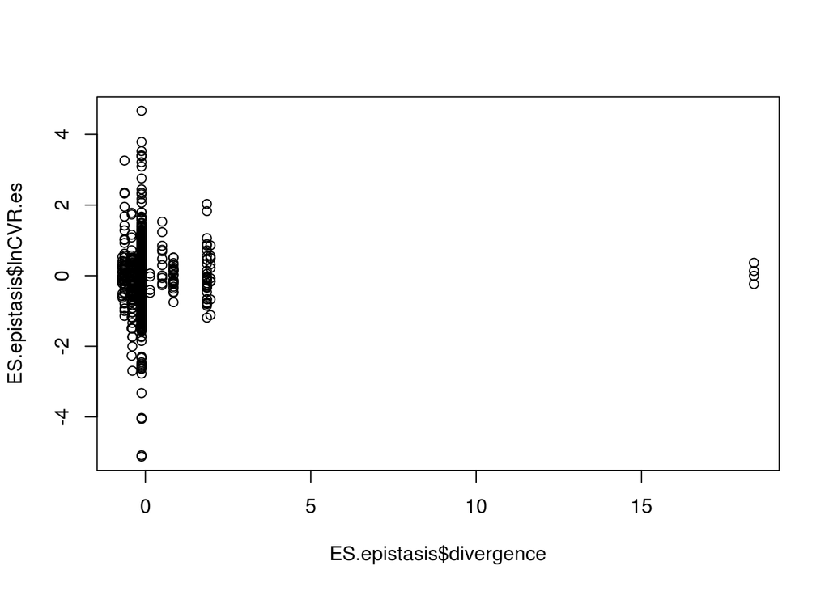

```r
# Does genetic divergence have linear effect on F1 variance?
plot(y = ES.epistasis$lnCVR.es, x = ES.epistasis$divergence)
```

```r
########################################
# random effect model
########################################
epi_random <- rma.mv(yi = lnCVR.es, V = lnCVR.sv.corF,
                     data = ES.epistasis, method = "REML",
                     random = list(~1 | spL.name, ~1 | Study.ID, ~1 | ES.ID)
                     )
summary(epi_random)
```

```
##
## Multivariate Meta-Analysis Model (k = 1059; method: REML)
##
##     logLik    Deviance         AIC         BIC        AICc
## -1839.1205   3678.2410   3686.2410   3706.0976   3686.2790
##
## Variance Components:
##
##             estim    sqrt  nlvls  fixed    factor
## sigma^2.1  0.0070  0.0836     42     no  spL.name
## sigma^2.2  0.0365  0.1910     24     no  Study.ID
## sigma^2.3  0.4439  0.6663    420     no     ES.ID
##
## Test for Heterogeneity:
## Q(df = 1058) = 11427.4931, p-val < .0001
##
## Model Results:
##
## estimate      se     zval    pval    ci.lb   ci.ub
##  -0.0340  0.0684  -0.4973  0.6190  -0.1680  0.1000
##
## ---
## Signif. codes:  0 '***' 0.001 '**' 0.01 '*' 0.05 '.' 0.1 ' ' 1
```

```r
########################################
# phylogenetic random effect model
########################################
epi_phyl.random <- rma.mv(yi = lnCVR.es, V = lnCVR.sv.corF,
                     data = ES.epistasis, method = "REML",
                     random = list(~1 | spL.name, ~1 | Study.ID, ~1 | ES.ID),
                     R = list(spL.name = tree.spL.epistasis.random.cor)
                     )
summary(epi_phyl.random)
```

```
##
## Multivariate Meta-Analysis Model (k = 1059; method: REML)
##
##     logLik    Deviance         AIC         BIC        AICc
## -1839.5559   3679.1118   3687.1118   3706.9683   3687.1498
##
## Variance Components:
##
##             estim    sqrt  nlvls  fixed    factor    R
## sigma^2.1  0.0000  0.0001     42     no  spL.name  yes
## sigma^2.2  0.0415  0.2038     24     no  Study.ID   no
## sigma^2.3  0.4473  0.6688    420     no     ES.ID   no
##
## Test for Heterogeneity:
## Q(df = 1058) = 11427.4931, p-val < .0001
##
## Model Results:
##
## estimate      se     zval    pval    ci.lb   ci.ub
##  -0.0354  0.0689  -0.5135  0.6076  -0.1703  0.0996
##
## ---
## Signif. codes:  0 '***' 0.001 '**' 0.01 '*' 0.05 '.' 0.1 ' ' 1
```

```r
# I^2 see http://www.metafor-project.org/doku.php/tips:i2_multilevel_multivariate?s[]=rma&s[]=mv&s[]=i2
# could not be calculated: too large dataset??
# W <- diag(1/ES.epistasis$lnCVR.sv.corF)
# X <- model.matrix(epi_phyl.random)
# P <- W - W %*% X %*% solve(t(X) %*% W %*% X) %*% t(X) %*% W
# 100 * sum(epi_phyl.random$sigma2) / (sum(epi_phyl.random$sigma2) +                                       (epi_phyl.random$k-epi_phyl.random$p)/sum(diag(P)))

########################################
# regression with random effect including phylogeny
########################################
epi_random.reg <- rma.mv(yi = lnCVR.es, V = lnCVR.sv.corF,
                         mods = ~divergence + trait.type + lnL.lnS + surv.relat.hyb + hetero.males,
                         method = "REML", data = ES.epistasis,
                         random = list(~1 | spL.name, ~1 | Study.ID, ~1 | ES.ID),
                         R = list(spL.name = tree.spL.epistasis.random.cor)
                         )
summary(epi_random.reg)
```

```
##
## Multivariate Meta-Analysis Model (k = 194; method: REML)
##
##    logLik   Deviance        AIC        BIC       AICc
## -293.2730   586.5461   604.5461   633.6741   605.5573
##
## Variance Components:
##
##             estim    sqrt  nlvls  fixed    factor    R
## sigma^2.1  1.7149  1.3095     11     no  spL.name  yes
## sigma^2.2  0.0000  0.0001      6     no  Study.ID   no
## sigma^2.3  0.2039  0.4516     57     no     ES.ID   no
##
## Test for Residual Heterogeneity:
## QE(df = 188) = 2769.2440, p-val < .0001
##
## Test of Moderators (coefficient(s) 2:6):
## QM(df = 5) = 73.4371, p-val < .0001
##
## Model Results:
##
##                 estimate      se     zval    pval    ci.lb    ci.ub
## intrcpt           0.3012  0.9782   0.3080  0.7581  -1.6159   2.2184
## divergence       -1.1557  0.2885  -4.0057  <.0001  -1.7213  -0.5902  ***
## trait.type       -0.0605  0.5348  -0.1131  0.9100  -1.1086   0.9877
## lnL.lnS          -0.2724  0.2217  -1.2285  0.2192  -0.7070   0.1622
## surv.relat.hyb   -0.5372  0.0637  -8.4389  <.0001  -0.6620  -0.4125  ***
## hetero.males      0.2279  0.4750   0.4798  0.6314  -0.7031   1.1588
##
## ---
## Signif. codes:  0 '***' 0.001 '**' 0.01 '*' 0.05 '.' 0.1 ' ' 1
```

```r
########################################
# effect of species
########################################
# This basically uses spL.name as a factor and "-1" will make it return an intercept estimate for every level of this factor
rma.mv(yi = lnCVR.es, V = lnCVR.sv.corF,
       mods = ~spL.name -1,
       method = "REML", data = ES.epistasis,
       random = list(~1 | spL.name, ~1 | Study.ID, ~1 | ES.ID),
       R = list(spL.name = tree.spL.epistasis.random.cor)
       )
```

```
##
## Multivariate Meta-Analysis Model (k = 1059; method: REML)
##
## Variance Components:
##
##             estim    sqrt  nlvls  fixed    factor    R
## sigma^2.1  0.1403  0.3746     42     no  spL.name  yes
## sigma^2.2  0.0000  0.0001     24     no  Study.ID   no
## sigma^2.3  0.4620  0.6797    420     no     ES.ID   no
##
## Test for Residual Heterogeneity:
## QE(df = 1017) = 7397.6674, p-val < .0001
##
## Test of Moderators (coefficient(s) 1:42):
## QM(df = 42) = 38.8770, p-val = 0.6088
##
## Model Results:
##
##                                            estimate      se     zval
## spL.nameAgrotis_ipsilon                     -0.0933  0.5101  -0.1829
## spL.nameAgrotis_segetum                     -0.0080  0.4472  -0.0179
## spL.nameChorthippus_biguttulus               0.8998  0.4836   1.8608
## spL.nameChorthippus_brunneus                -0.1922  0.5075  -0.3787
## spL.nameChorthippus_parallelus_eythropus    -0.1506  0.4027  -0.3739
## spL.nameChorthippus_parallelus_parallelus   -0.2808  0.4683  -0.5997
## spL.nameChrysoperla_johnsoni                 0.0215  0.5457   0.0394
## spL.nameChrysoperla_plorabunda              -0.5159  0.5458  -0.9452
## spL.nameCoturnix_coturnix_coturnix          -0.1408  0.4550  -0.3095
## spL.nameCoturnix_coturnix_japonica          -0.1837  0.4118  -0.4462
## spL.nameDrosophila_auraria                  -0.8399  0.4547  -1.8474
## spL.nameDrosophila_biauraria                -0.8511  0.6102  -1.3949
## spL.nameDrosophila_flavomontana              0.2214  0.4508   0.4912
## spL.nameDrosophila_kanekoi                  -0.1239  0.5673  -0.2184
## spL.nameDrosophila_lacicola                 -0.2684  0.8062  -0.3329
## spL.nameDrosophila_littoralis               -0.1340  0.4636  -0.2892
## spL.nameDrosophila_lummei                    0.2297  0.7909   0.2904
## spL.nameDrosophila_mauritiana               -0.0047  0.7769  -0.0061
## spL.nameDrosophila_montana                   0.3056  0.5276   0.5792
## spL.nameDrosophila_persimilis                0.0472  0.7765   0.0608
## spL.nameDrosophila_quadraria                -0.3874  0.7779  -0.4981
```

[output cut: 52 more lines]

```
## spL.nameHaplochromis_nubilus               0.6853  -1.2125  1.8447
## spL.nameHyla_chrysoscelis                  0.1205  -0.2244  1.9353
## spL.nameHyla_femoralis                     0.3209  -0.6019  1.8372
## spL.nameLaupala_kohalensis                 0.7593  -1.0786  0.7870
## spL.nameLaupala_paranigra                  0.6939  -1.2113  0.8062
## spL.nameMus_musculus_domesticus            0.4728  -1.0150  0.4708
## spL.nameMus_musculus_musculus              0.8927  -0.8131  0.7083
## spL.namePundamilia_nyererei                0.3172  -0.5891  1.8171
## spL.namePundamilia_pundamilia              0.3795  -0.8436  2.2150
## spL.nameSpodoptera_latifascia              0.7873  -1.7414  1.3199
## spL.nameTeleogryllus_commodus              0.8893  -1.0246  0.8887
## spL.nameTeleogryllus_oceanicus             0.9404  -1.1240  1.0414
##
## ---
## Signif. codes:  0 '***' 0.001 '**' 0.01 '*' 0.05 '.' 0.1 ' ' 1
```

```r
##############################################
# Output
##############################################

# random effect model
epi_r <- cbind(epi_random$beta,   # estimate
               epi_random$ci.lb,  # 95ci
               epi_random$ci.ub,  # 95ci
               "meta-analysis",
               "meta-analytic mean"
               )
colnames(epi_r) <- c("estimate", "ci.lb", "ci.ub", "type","factors")
row.names(epi_r) <- "meta-analysis"
write.table(epi_r, "../Analysis/random_epi.csv",
            sep = ",", quote = F, row.names = T)

# meta-regression
epistasis.reg <- cbind(epi_random.reg$beta,   # estimate
                       epi_random.reg$ci.lb,  # 95ci
                       epi_random.reg$ci.ub,  # 95ci
                       "meta-regression"
                       )
epistasis.reg <- cbind(epistasis.reg,
                   rownames(epistasis.reg) # factors
                   )
colnames(epistasis.reg) <- c("estimate", "ci.lb", "ci.ub", "type", "factors")
write.table(epistasis.reg, "../Analysis/reg.epistasis.csv",
            sep = ",", quote = F, row.names = T)

# all
epistasis <- rbind(epi_r, epistasis.reg)
write.table(epistasis, "../Analysis/epistasis.csv",
            sep = ",", quote = F, row.names = T)
```

# Maternal or Paternal

Supplemental for hypothesis 1.  
Do hybrids resemble to mother species, or father species?

To examine this, compare the differences  
between hybrid and its mother species vs.  
between hybrid and its father species

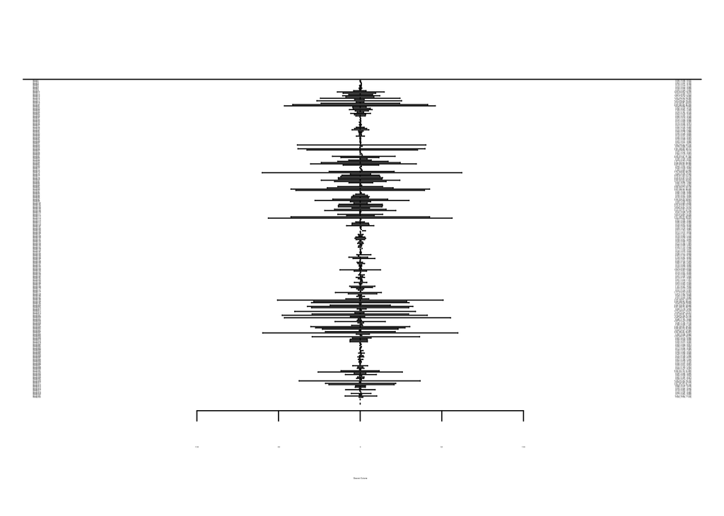

```r
################################################
# meta-analysis
################################################


########################################
# forest plot
########################################
forest(ES.matpat.2$lnRR.dist.mother.es, ES.matpat.2$lnRR.dist.mother.sv)
```

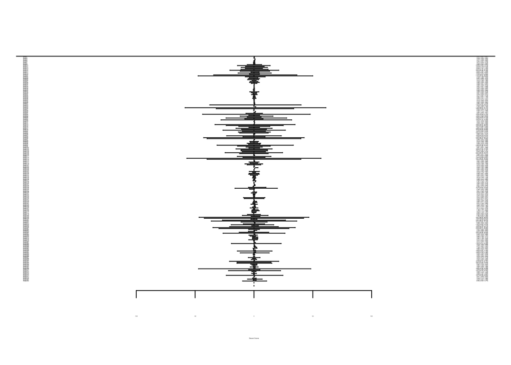

```r
forest(ES.matpat.2$lnRR.dist.father.es, ES.matpat.2$lnRR.dist.father.sv)
```

```r
########################################
# fixed effect model
########################################
maternal_fix <- rma(yi = lnRR.dist.mother.es, vi = lnRR.dist.mother.sv,
                    method = "FE", data = ES.matpat.2)
summary(maternal_fix)
```

```
##
## Fixed-Effects Model (k = 252)
##
##     logLik    deviance         AIC         BIC        AICc
## -4700.5317   8992.7050   9403.0635   9406.5929   9403.0795
##
## Test for Heterogeneity:
## Q(df = 251) = 8992.7050, p-val < .0001
##
## Model Results:
##
## estimate      se     zval    pval   ci.lb   ci.ub
##   0.3598  0.0042  84.7530  <.0001  0.3515  0.3681  ***
##
## ---
## Signif. codes:  0 '***' 0.001 '**' 0.01 '*' 0.05 '.' 0.1 ' ' 1
```

```r
paternal_fix <- rma(yi = lnRR.dist.father.es, vi = lnRR.dist.father.sv,
                    method = "FE", data = ES.matpat.2)
summary(paternal_fix)
```

```
##
## Fixed-Effects Model (k = 240)
##
##     logLik    deviance         AIC         BIC        AICc
## -3609.0988   6831.5257   7220.1977   7223.6783   7220.2145
##
## Test for Heterogeneity:
## Q(df = 239) = 6831.5257, p-val < .0001
##
## Model Results:
##
## estimate      se     zval    pval   ci.lb   ci.ub
##   0.1863  0.0040  46.8005  <.0001  0.1785  0.1941  ***
##
## ---
## Signif. codes:  0 '***' 0.001 '**' 0.01 '*' 0.05 '.' 0.1 ' ' 1
```

```r
########################################
# random effect model
########################################
maternal_random <- rma(yi = lnRR.dist.mother.es, vi = lnRR.dist.mother.sv,
                    method = "REML", data = ES.matpat.2)
summary(maternal_random)
```

```
##
## Random-Effects Model (k = 252; tau^2 estimator: REML)
##
##    logLik   deviance        AIC        BIC       AICc
## -394.3012   788.6025   792.6025   799.6534   792.6509
##
## tau^2 (estimated amount of total heterogeneity): 0.1033 (SE = 0.0177)
## tau (square root of estimated tau^2 value):      0.3214
## I^2 (total heterogeneity / total variability):   95.59%
## H^2 (total variability / sampling variability):  22.65
##
## Test for Heterogeneity:
## Q(df = 251) = 8992.7050, p-val < .0001
##
## Model Results:
##
## estimate      se    zval    pval   ci.lb   ci.ub
##   0.2336  0.0347  6.7401  <.0001  0.1657  0.3015  ***
##
## ---
## Signif. codes:  0 '***' 0.001 '**' 0.01 '*' 0.05 '.' 0.1 ' ' 1
```

```r
paternal_random <- rma(yi = lnRR.dist.father.es, vi = lnRR.dist.father.sv,
                    method = "REML", data = ES.matpat.2)
summary(paternal_random)
```

```
##
## Random-Effects Model (k = 240; tau^2 estimator: REML)
##
##    logLik   deviance        AIC        BIC       AICc
## -369.7478   739.4957   743.4957   750.4486   743.5465
##
## tau^2 (estimated amount of total heterogeneity): 0.0969 (SE = 0.0175)
## tau (square root of estimated tau^2 value):      0.3114
## I^2 (total heterogeneity / total variability):   95.98%
## H^2 (total variability / sampling variability):  24.88
##
## Test for Heterogeneity:
## Q(df = 239) = 6831.5257, p-val < .0001
##
## Model Results:
##
## estimate      se    zval    pval   ci.lb   ci.ub
##   0.2822  0.0352  8.0167  <.0001  0.2132  0.3512  ***
##
## ---
## Signif. codes:  0 '***' 0.001 '**' 0.01 '*' 0.05 '.' 0.1 ' ' 1
```

```r
########################################
# phylogenetic random effect model
########################################
## mother species vs hybrids
mat.phyl.random <- rma.mv(yi = lnRR.dist.mother.es, V = lnRR.dist.mother.sv,
                          data = ES.matpat.2, method = "REML",
                          random = list(~1 | spL.name, ~1 | Study.ID),
                          R = list(spL.name = tree.spL.matpat.random.cor)
                          )
summary(mat.phyl.random)
```

```
##
## Multivariate Meta-Analysis Model (k = 252; method: REML)
##
##     logLik    Deviance         AIC         BIC        AICc
## -2024.4810   4048.9619   4054.9619   4065.5383   4055.0591
##
## Variance Components:
##
##             estim    sqrt  nlvls  fixed    factor    R
## sigma^2.1  1.3240  1.1506     33     no  spL.name  yes
## sigma^2.2  0.0000  0.0002     20     no  Study.ID   no
##
## Test for Heterogeneity:
## Q(df = 251) = 8992.7050, p-val < .0001
##
## Model Results:
##
## estimate      se    zval    pval    ci.lb   ci.ub
##   0.2576  0.6481  0.3975  0.6910  -1.0126  1.5279
##
## ---
## Signif. codes:  0 '***' 0.001 '**' 0.01 '*' 0.05 '.' 0.1 ' ' 1
```

```r
## father species vs hybrids with random effects
pat.phyl.random  <- rma.mv(yi = lnRR.dist.father.es, V = lnRR.dist.father.sv,
                           data = ES.matpat.2, method = "REML",
                           random = list(~1 | spL.name, ~1 | Study.ID),
                           R = list(spL.name = tree.spL.matpat.random.cor)
                           )
summary(pat.phyl.random)
```

```
##
## Multivariate Meta-Analysis Model (k = 240; method: REML)
##
##     logLik    Deviance         AIC         BIC        AICc
## -1789.0419   3578.0839   3584.0839   3594.5133   3584.1860
##
## Variance Components:
##
##             estim    sqrt  nlvls  fixed    factor    R
## sigma^2.1  0.2278  0.4773     33     no  spL.name  yes
## sigma^2.2  0.0337  0.1835     20     no  Study.ID   no
##
## Test for Heterogeneity:
## Q(df = 239) = 6831.5257, p-val < .0001
##
## Model Results:
##
## estimate      se    zval    pval    ci.lb   ci.ub
##   0.2391  0.2740  0.8725  0.3829  -0.2980  0.7761
##
## ---
## Signif. codes:  0 '***' 0.001 '**' 0.01 '*' 0.05 '.' 0.1 ' ' 1
```

```r
## combine above two
comp.matpat <- data.frame(estimate = c(coef(mat.phyl.random), coef(pat.phyl.random)),
                          stderror = c(mat.phyl.random$se, pat.phyl.random$se),
                          meta = c("diff.mother.hyb", "diff.father.hyb"),
                          tau2 = c(mat.phyl.random$tau2, pat.phyl.random$tau2))

##########################################################
# meta-analysis comparing phenotypic difference between
# mother species - hybrids  vs  father species vs hybrids
##########################################################
rma(yi = estimate, sei = stderror, mods = ~ meta,
    method = "FE", data = comp.matpat)
```

```
##
## Fixed-Effects with Moderators Model (k = 2)
##
## Test for Residual Heterogeneity:
## QE(df = 0) = 0.0000, p-val = 1.0000
##
## Test of Moderators (coefficient(s) 2):
## QM(df = 1) = 0.0007, p-val = 0.9789
##
## Model Results:
##
##                      estimate      se    zval    pval    ci.lb   ci.ub
## intrcpt                0.2391  0.2740  0.8725  0.3829  -0.2980  0.7761
## metadiff.mother.hyb    0.0186  0.7036  0.0264  0.9789  -1.3605  1.3977
##
## ---
## Signif. codes:  0 '***' 0.001 '**' 0.01 '*' 0.05 '.' 0.1 ' ' 1
```

There was no significant difference between paternal (similarity between hybrids and father species) and maternal inheritance (that of hybrids and mother species).